# Showcasing Neo4j with Jupyter Notebook

In this Report, we will be showing how to use Cypher in Neo4j and also using Python to iterate through different Cypher Queries.

For this Report, we will be using the common database known to Neo4j which is is the **Movie DBMS**

### Libraries to be Used

```python
from py2neo import Graph,Node,Relationship
from neo4j import GraphDatabase
import networkx as nx
import matplotlib.pyplot as plt
```

### Connecting to a Local Neo4j Server

I have a local Neo4j Server which have the Movie Graph Database Running on the background, we will be using the following credentials to connect to the server by using the python library called py2neo.

URL: "bolt://localhost:7687"

username: "neo4j"

password: "123456"

```python
if Graph("bolt://localhost:7687", auth=("neo4j", "123456")):
    graph = Graph("bolt://localhost:7687", auth=("neo4j", "123456"))
    print('Connected to Neo4j Server')
else:
    print('Not Connected')
```

```
Connected to Neo4j Server
```

## Using Cypher Queries

The good thing in using the py2neo is that we can directly use Cypher code queries to directly retrieve results from the database itself and by using it with the a jupyter notebook, we can create a seamless technical report by showing the results in different ways such as a List of a table or dictionary. using both Neo4j and Anaconda.

Sample Cypher Queries as follows:

```python
#Checking what kinds of labels are in the database

#we can show it by transforming in to a dictionary
graph.run("CALL db.labels").data()
```

```
[{'label': 'Movie'}, {'label': 'Person'}, {'label': 'Greeting'}]
```

```python
#or we can show it in a table

graph.run("CALL db.labels")
```

| label |
| --- |
| Movie |
| Person |
| Greeting |

From here we see that we have at 3 labels. Let us check the content of each labels.

```python
graph.run("""
Match (n:Movie)
Return n
Limit 5
""").data()
```

```
[{'n': Node('Movie', released=1999, tagline='Welcome to the Real World', title='The Matrix')},
 {'n': Node('Movie', released=2003, tagline='Free your mind', title='The Matrix Reloaded')},
 {'n': Node('Movie', released=2003, tagline='Everything that has a beginning has an end', title='The Matrix Revolutions')},
 {'n': Node('Movie', released=1997, tagline='Evil has its winning ways', title="The Devil's Advocate")},
 {'n': Node('Movie', released=1992, tagline="In the heart of the nation's capital, in a courthouse of the U.S. government, one man will stop at nothing to keep his honor, and one will stop at nothing to find the truth.", title='A Few Good Men')}]
```

```python
graph.run("""
Match (n:Person)
Return n
Limit 5
""").data()
```

```
[{'n': Node('Person', born=1964, name='Keanu Reeves')},
 {'n': Node('Person', born=1967, name='Carrie-Anne Moss')},
 {'n': Node('Person', born=1961, name='Laurence Fishburne')},
 {'n': Node('Person', born=1960, name='Hugo Weaving')},
 {'n': Node('Person', born=1967, name='Andy Wachowski')}]
```

```python
graph.run("""
Match (n:Greetings)
Return n
""").data()
```

```
[]
```

We can now proceed to a more advance Cypher Query to Filter the data.

We will try to ask some questions and create cypher codes.

**What Movies in the Database are released within 1997 to 2000 and show only the year released and title of the movie?**

```python
graph.run("""
Match (n:Movie)
WHERE n.released >= 1997 and n.released <=2000
Return n.released, n.title
""").data()
```

```
[{'n.released': 1999, 'n.title': 'The Matrix'},
 {'n.released': 1997, 'n.title': "The Devil's Advocate"},
 {'n.released': 2000, 'n.title': 'Jerry Maguire'},
 {'n.released': 1997, 'n.title': 'As Good as It Gets'},
 {'n.released': 1998, 'n.title': 'What Dreams May Come'},
 {'n.released': 1999, 'n.title': 'Snow Falling on Cedars'},
 {'n.released': 1998, 'n.title': "You've Got Mail"},
 {'n.released': 1998, 'n.title': 'When Harry Met Sally'},
 {'n.released': 2000, 'n.title': 'The Replacements'},
 {'n.released': 1999, 'n.title': 'The Green Mile'},
 {'n.released': 2000, 'n.title': 'Cast Away'},
 {'n.released': 1999, 'n.title': 'Bicentennial Man'}]
```

**How many are those movies?**

```python
graph.run("""
Match (n:Movie)
WHERE n.released >= 1997 and n.released <=2000
Return count(n)
""").data()
```

```
[{'count(n)': 12}]
```

**What Movies in the Database has a Title that starts with "The" and show from the most recent to old?**

```python
graph.run("""
Match (n:Movie)
WHERE n.title =~ 'The.+'
Return n.released,n.title
ORDER BY n.released DESC
""").data()
```

```
[{'n.released': 2006, 'n.title': 'The Da Vinci Code'},
 {'n.released': 2004, 'n.title': 'The Polar Express'},
 {'n.released': 2003, 'n.title': 'The Matrix Reloaded'},
 {'n.released': 2003, 'n.title': 'The Matrix Revolutions'},
 {'n.released': 2000, 'n.title': 'The Replacements'},
 {'n.released': 1999, 'n.title': 'The Matrix'},
 {'n.released': 1999, 'n.title': 'The Green Mile'},
 {'n.released': 1997, 'n.title': "The Devil's Advocate"},
 {'n.released': 1996, 'n.title': 'The Birdcage'}]
```

**What Movies has the word 'heart' on its tagline?**

```python
graph.run("""
Match (n:Movie)
WHERE n.tagline =~ '.+ heart.+'
Return n.title,n.tagline
""").data()
```

```
[{'n.title': 'A Few Good Men',
  'n.tagline': "In the heart of the nation's capital, in a courthouse of the U.S. government, one man will stop at nothing to keep his honor, and one will stop at nothing to find the truth."},
 {'n.title': 'As Good as It Gets',
  'n.tagline': 'A comedy from the heart that goes for the throat.'}]
```

With the above example, we can show that we can use advance filtering queries in jupyter notebook with Cypher.

### Showing Relationships with other Labels

First let us show what relationship are there in the database.

```python
graph.run("""
MATCH (n)-[r]-()
RETURN DISTINCT TYPE(r)
""").data()
```

```
[{'TYPE(r)': 'ACTED_IN'},
 {'TYPE(r)': 'PRODUCED'},
 {'TYPE(r)': 'DIRECTED'},
 {'TYPE(r)': 'WROTE'},
 {'TYPE(r)': 'REVIEWED'},
 {'TYPE(r)': 'FOLLOWS'}]
```

We have at least 6 relationships or connections

**What Movies did Keanu Reeves ACTED In? Sort by Most Recent.**

```python
graph.run("""
Match (n:Movie)-[:ACTED_IN]-(n1:Person{name:'Keanu Reeves'})
Return n.released,n.title
ORDER BY n.released DESC
""").data()
```

```
[{'n.released': 2003, 'n.title': "Something's Gotta Give"},
 {'n.released': 2003, 'n.title': 'The Matrix Revolutions'},
 {'n.released': 2003, 'n.title': 'The Matrix Reloaded'},
 {'n.released': 2000, 'n.title': 'The Replacements'},
 {'n.released': 1999, 'n.title': 'The Matrix'},
 {'n.released': 1997, 'n.title': "The Devil's Advocate"},
 {'n.released': 1995, 'n.title': 'Johnny Mnemonic'}]
```

```python
graph.run("""
Match (direct)-[:DIRECTED]->(n:Movie)-[:ACTED_IN]-(n1:Person{name:'Keanu Reeves'})
WHERE n.released >=1997 and n.released <=2000
Return direct.name as Director,n.title as Title,n.released as Year
ORDER BY n.released DESC
""").data()
```

```
[{'Director': 'Howard Deutch', 'Title': 'The Replacements', 'Year': 2000},
 {'Director': 'Lana Wachowski', 'Title': 'The Matrix', 'Year': 1999},
 {'Director': 'Andy Wachowski', 'Title': 'The Matrix', 'Year': 1999},
 {'Director': 'Taylor Hackford',
  'Title': "The Devil's Advocate",
  'Year': 1997}]
```

```python
graph.run("""
Match (direct:Person)-[:DIRECTED]-()
WHERE NOT (direct)-[:DIRECTED]->()-[:ACTED_IN]-(:Person{name:'Keanu Reeves'})
Return DISTINCT(direct.name) as Directors
""").data()
```

```
[{'Directors': 'James Marshall'},
 {'Directors': 'Rob Reiner'},
 {'Directors': 'Tony Scott'},
 {'Directors': 'Cameron Crowe'},
 {'Directors': 'James L. Brooks'},
 {'Directors': 'Werner Herzog'},
 {'Directors': 'Vincent Ward'},
 {'Directors': 'Scott Hicks'},
 {'Directors': 'Tom Hanks'},
 {'Directors': 'Nora Ephron'},
 {'Directors': 'John Patrick Stanley'},
 {'Directors': 'Mike Nichols'},
 {'Directors': 'Clint Eastwood'},
 {'Directors': 'Tom Tykwer'},
 {'Directors': 'Ron Howard'},
 {'Directors': 'Frank Darabont'},
 {'Directors': 'Danny DeVito'},
 {'Directors': 'Jan de Bont'},
 {'Directors': 'Robert Zemeckis'},
 {'Directors': 'Milos Forman'},
 {'Directors': 'Chris Columbus'},
 {'Directors': 'Penny Marshall'}]
```

**Find the Shortest Connection Link between Keanu Reeves and Carrie-Anne Moss?**

```python
graph.run("""
MATCH cl=shortestPath((n1:Person {name:"Keanu Reeves"})-[*]-(n2:Person {name:"Carrie-Anne Moss"}))
RETURN cl
""").data()[0]['cl']
```

[output not shown]

### Using CREATE, DELETE and SET Parameters with Neo4j and Jupyter Notebook

Through jupyter notebook you could already get also used the functions of Neo4j of creating a table/graph database, delete a parameter within the database and also set new parameters.

**Let us Create a new Label within the Movide Database**

```python
graph.run("""
CREATE (RalphCaubalejo:Extras {name:'Ralph Caubalejo', purpose:'testing'})
""").data()
```

```
[]
```

```python
#testing if the new label is created:
graph.run("CALL db.labels").data()
```

```
[{'label': 'Movie'},
 {'label': 'Person'},
 {'label': 'Greeting'},
 {'label': 'Extras'}]
```

Notice that the label 'Extras' has already been added to to the list of labels

```python
#getting the new entry we inputted
graph.run("""
MATCH (n1:Extras)
Return n1
""").data()
```

```
[{'n1': Node('Extras', name='Ralph Caubalejo', purpose='testing')}]
```

Notice also that the specific node is already added.

**Adding New Parameters/Property**

```python
#getting the new entry we inputted
graph.run("""
MATCH (n1:Extras)
SET n1.trial= 'testing version 2'
Return n1
""").data()
```

```
[{'n1': Node('Extras', name='Ralph Caubalejo', purpose='testing', trial='testing version 2')}]
```

Notice that we were able to add a specific property in the node easily with the usage of the jupyter notebook and also visualize the results faster.

**Deleting the Node**

```python
#delete the node
graph.run("""
MATCH (n1:Extras)
DETACH DELETE n1
""").data()
```

```
[]
```

```python
graph.run("""
MATCH (n1:Extras)
Return n1
""").data()
```

```
[]
```

Notice that there is no data collected anymore since we have deleted it already.

## Integration of Python Automation Functions to Neo4j Cypher

One of the goods things of using Neo4j and Cypher n Jupyter Notebook is that you can interlink different python functions such for loop and if else statement in creating your table or filtering your databases.

Some examples below:

**For Loop and Entry Database/Table Creation**

```python
for x in ['A','B','C','D','E']:
    graph.run("""
    CREATE (:Extras {name:$x1})
    """,x1=x)
```

```python
graph.run("""
MATCH (n1:Extras)
Return n1
""").data()
```

```
[{'n1': Node('Extras', name='A')},
 {'n1': Node('Extras', name='B')},
 {'n1': Node('Extras', name='C')},
 {'n1': Node('Extras', name='D')},
 {'n1': Node('Extras', name='E')}]
```

Notice that we were able to input and create the nodes in the list far easier by using the iteration loop rather than having a long cypher code or individual codes for each node.

Also when using the Jupyter Notebook, it is easier to create visualization of the data retrieved in to suitable graph or network visualization using a more advanced library in python such as networkx.

**Using Neo4J and NetworkX**

```python
driver = GraphDatabase.driver('bolt://localhost:7687', auth=("neo4j", "123456"))

result = driver.session().run("""
MATCH (n)-[r]->(c)
RETURN *
""")
```

```python
G = nx.MultiDiGraph()
nodes = list(result.graph()._nodes.values())
for node in nodes:
    G.add_node(node.id, labels=node._labels)
edges = list(result.graph()._relationships.values())
for edge in edges:
    G.add_edge(edge.start_node.id, edge.end_node.id)
```

**Visualize the Network**

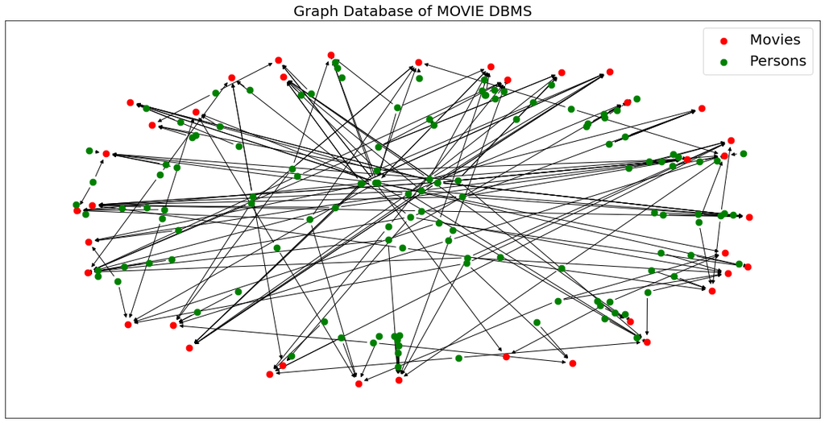

```python
G1=[]
G2=[]
for y in list(G.nodes('labels')):
    if str(y[1]) == "frozenset({'Movie'})":
        G1.append(y[0])
    else:
        G2.append(y[0])

pos = nx.fruchterman_reingold_layout(G,seed=1);
plt.figure(figsize=(20,10),linewidth=10);
nx.draw_networkx_nodes(G1, pos, node_size=75, node_color="Red",label='Movies');
nx.draw_networkx_nodes(G2, pos, node_size=75, node_color="Green",label='Persons');
nx.draw_networkx_edges(G, pos);
plt.title('Graph Database of MOVIE DBMS',fontsize=20)
plt.legend(fontsize=20)
plt.show();
```